# P4：拍拍贷业务数据探索

#### 数据集来源：https://github.com/udacity/new-dand-advanced-china/blob/master/探索性数据分析/项目/探索性数据分析_数据集.md

# 数据说明：

【数据用途】 所提供数据为拍拍贷真实业务数据，但仅为信用标的一个样本，仅供数据分析和学术研究目的使用，而非信息披露。从这个数据中推导得到的结果不反映拍拍贷平台的整体情况，也不代表拍拍贷官方的态度。

【数据描述】 所提供数据包含了成交时间从2015年1月1日到2017年1月30日的328553支信用标。

### LCIS (Loan Characteristics Investment Status ) 表：

所提供数据包含了该客户投资的从2015年1月1日起成交的所有标。 以6个月月底的最后一天（2016年9月30日，2016年10月31日，2016年11月30日，2016年12月31日，2017年1月31日，2017年2月28日）作为recorddate，对每一个recorddate都提供了该客户投资的从2015年1月1日起到当天成交的所有标的数据，包括这些标成交时的特点（Loan Characteristics）、该客户投资的金额以及截至当天的收款情况（Investment Status）。

```r
ppd_LCIS_dict[,c(3,5)]
```

| 字段名 | 字段注释 |
| --- | --- |
| ListingId | 列表序号，为列表的唯一键。 |
| 借款金额 | 列表成交总金额。 |
| 借款期限 | 总的期数（按月计）。 |
| 借款利率 | 年化利率（百分数）。 |
| 借款成功日期 | 列表成交的日期。都在2015年1月1日以后。 |
| 初始评级 | 列表成交时的信用评级。AAA为安全标，AA为赔标，A-F为信用等级。 |
| 借款类型 | 分为'应收安全标'，‘电商’，‘APP闪电’，‘普通’和‘其他’。 |
| 是否首标 | 该标是否为借款人首标。 |
| 年龄 | 借款人在该列表借款成功时的年龄。 |
| 性别 | 该列表借款人性别。 |
| 手机认证 | 该列表借款人手机实名认证是否成功。 |
| 户口认证 | 该列表借款人户口认证是否成功。 |
| 视频认证 | 该列表借款人视频认证是否成功。 |
| 学历认证 | 该列表借款人学历认证是否成功。成功则表示有大专及以上学历。 |
| 征信认证 | 该列表借款人征信认证是否成功。成功则表示有人行征信报告。 |
| 淘宝认证 | 该列表借款人淘宝认证是否成功。成功则表示为淘宝店主。 |
| 历史成功借款次数 | 借款人在该列表成交之前的借款成功次数。 |
| 历史成功借款金额 | 借款人在该列表成交之前的借款成功金额。 |
| 总待还本金 | 借款人在该列表成交之前待还本金金额。 |
| 历史正常还款期数 | 借款人在该列表成交之前的按期还款期数。 |
| 历史逾期还款期数 | 借款人在该列表成交之前的逾期还款期数。 |
| 我的投资金额 | 该投资人对该列表的投资金额。 |
| 当前到期期数 | 该列表当前应还的期数。 |
| 当前还款期数 | 该列表已经成功还款的期数。 |
| 已还本金 | 已经向该投资人成功还款的本金总额。 |
| 已还利息 | 已经向该投资人成功还款的利息总额。 |
| 待还本金 | 还需向该投资人还款的本金总额。 |
| 待还利息 | 还需向该投资人还款的利息总额。 |
| 标当前逾期天数 | 当期逾期天数。未逾期则为0。 |
| 标当前状态 | 当期状态。分为‘正常还款中’，‘逾期中’，‘已还清’，‘已债转’。 |
| 上次还款日期 | 上一次实际还款日期。 |
| 上次还款本金 | 上一次实际向该投资人还款本金。 |
| 上次还款利息 | 上一次实际向该投资人还款利息。 |
| 下次计划还款日期 | 下一次计划还款日期。 |
| 下次计划还款本金 | 下一次计划向该投资人还款本金。 |
| 下次计划还款利息 | 下一次计划向该投资人还款利息。 |
| recorddate | 记录日期。一般为月末最后一天。 |

LC部分共有21个字段，包括一个主键（listingid）、7个标的特征和13个成交当时的借款人信息，全部为成交当时可以获得的信息。

IS部分有15个字段，包括截至recorddate当天标的还款状态，针对这位客户的已还和待还金额，最近的还款情况和下一期还款计划。具体字段描述请见数据字典。

# 关于拍拍贷业务的开放式探索：

### 2.借款人特征与逾期还款率平均值的关系：

### 操作定义：逾期还款率平均值 = mean（逾期还款率）

### 3.借款人特征与人口坏账率的关系：

### 操作定义：（人口）坏账率 = （逾期超过90天的人口数）/（总人口数）

### 4.借款人特征与金额坏账率的关系：

### 操作定义：（金额）坏账率 = （逾期超过90天的总待还金额数）/（总借款金额）

## R库文件导入

```r
library(ggplot2)
library(dplyr)
library(openxlsx)
library(gridExtra)
```

## 读取数据

```r
list.files()
```

1. '123.csv'

2. 'LC.csv'

3. 'LCIS.csv'

4. 'LCIS数据字典.xlsx'

5. 'LCLP数据字典.xlsx'

6. 'LP.csv'

7. 'P4.ipynb'

8. 'ppd.png'

9. '数据说明.docx'

10. '用python3探索拍拍贷数据集.ipynb'

```r
ppd<-read.csv('LCIS.csv')
ppd_LCIS_dict<-read.xlsx('LCIS数据字典.xlsx',sheet=1)
```

## 数据概览：

```r
ppd[1,]
```

[output not shown]

```r
str(ppd)
```

```
'data.frame':	292539 obs. of  37 variables:
 $ ListingId       : int  1693100 1713229 1904026 2158281 2257194 2272036 2315058 2332817 2365175 2370723 ...
 $ 借款金额        : int  3629 3000 3629 3919 14000 40000 3200 3000 4260 11987 ...
 $ 借款期限        : int  6 12 12 12 12 6 3 6 7 12 ...
 $ 借款利率        : num  12 12 12 18 18 15 10 12 12 16 ...
 $ 借款成功日期    : Factor w/ 654 levels "2015/1/1","2015/1/10",..: 21 24 90 98 108 114 114 150 150 151 ...
 $ 初始评级        : Factor w/ 8 levels "A","AA","AAA",..: 2 2 2 5 5 4 2 2 2 4 ...
 $ 借款类型        : Factor w/ 5 levels "APP闪电","电商",..: 3 3 3 3 3 2 3 3 3 4 ...
 $ 是否首标        : Factor w/ 2 levels "否","是": 1 2 1 1 1 2 1 2 1 1 ...
 $ 年龄            : int  31 24 27 28 46 32 25 38 25 33 ...
 $ 性别            : Factor w/ 2 levels "男","女": 1 1 1 1 1 1 1 1 1 2 ...
 $ 手机认证        : Factor w/ 5 levels "成功认证","其他",..: 1 1 1 1 1 1 1 1 1 3 ...
 $ 户口认证        : Factor w/ 9 levels "本科","成功认证",..: 6 6 6 2 6 2 6 6 6 6 ...
 $ 视频认证        : Factor w/ 2 levels "成功认证","未成功认证": 2 2 2 2 2 1 2 2 1 2 ...
 $ 学历认证        : Factor w/ 2 levels "成功认证","未成功认证": 2 2 2 2 2 2 2 2 1 1 ...
```

[output cut: 23 more lines]

### 数据清洗：

#### 1.去除掉缺失值，找出历史成功借款次数大于0，历史正常还款期数大于0的数据，因为没有借款的数据没有意义。

#### 2.创建新变量逾期还款率=历史逾期还款期数/(历史正常还款期数+历史逾期还款期数)，为了了解平台借款人信用。

#### 3.标当前逾期天数<90的赋值0，>90的赋值1，为了求逾期还款率均值做准备。

#### 4.把初始评级'AAA','AA','A','B','C','D','E','F'依次次该为：1,2,3,4,5,6,7,8并且转化为数值，这样便于排序。

#### 5.把手机认证的因子转化为字符串，然后把已婚和未婚都赋值为成功认证。把其它从总数据集中过滤掉。

#### 6.把户口认证转化为字符串型，然后把所有学历都赋值为成功认证，未填写赋值成未成功认证。

```r
ppd$历史成功借款次数<-as.numeric(ppd$历史成功借款次数)
ppd<-subset(ppd,(历史成功借款次数>0)&(历史正常还款期数>0)&(!is.na(历史逾期还款期数))&(!is.na(历史正常还款期数)))
ppd<-transform(ppd,逾期还款率=历史逾期还款期数/(历史正常还款期数+历史逾期还款期数))
ppd<-subset(ppd,(逾期还款率!=Inf)&(逾期还款率<=1)&(!is.na(逾期还款率)))
ppd$标当前逾期天数[ppd$标当前逾期天数<90]<-0
ppd$标当前逾期天数[ppd$标当前逾期天数>=90]<-1
ppd$初始评级<-factor(ppd$初始评级,levels=c('AAA','AA','A','B','C','D','E','F'),labels=c(1,2,3,4,5,6,7,8))
ppd$初始评级<-as.numeric(ppd$初始评级)
ppd$历史成功借款金额<-as.numeric(ppd$历史成功借款金额)
ppd$手机认证<-as.character(ppd$手机认证)
ppd$手机认证[(ppd$手机认证=='已婚'|ppd$手机认证=='未婚')]<-'成功认证'
ppd<-subset(ppd,!(手机认证=='其他'))
ppd$户口认证<-as.character(ppd$户口认证)
ppd$户口认证[(ppd$户口认证=='本科'|ppd$户口认证=='初中及以下'|ppd$户口认证=='大专'|
          ppd$户口认证=='高中'|ppd$户口认证=='研究生或以上'|ppd$户口认证=='中专')]<-'成功认证'
ppd$户口认证[ppd$户口认证=='未填']<-'未成功认证'
```

# 借款人特征和逾期还款率的关系探索：

## 初始评级与逾期还款率的关系：

#### 备注：初始评级AAA-F已经依次被替换为1-8.

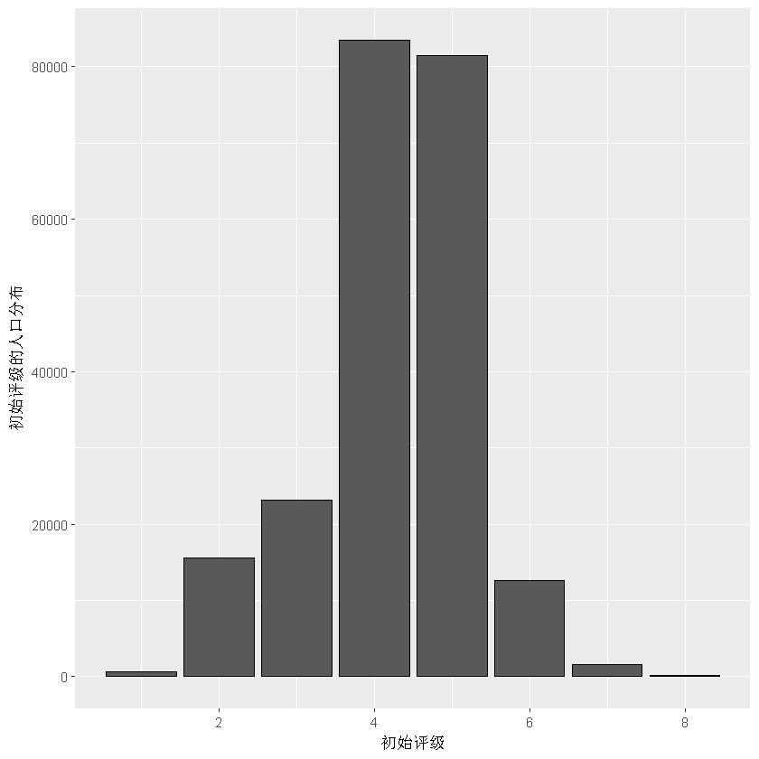

```r
ggplot(data=ppd,aes(x=初始评级))+
geom_bar(color='black')+
#scale_y_continuous(breaks=seq(1,8,1))+
ylab('初始评级的人口分布')
```

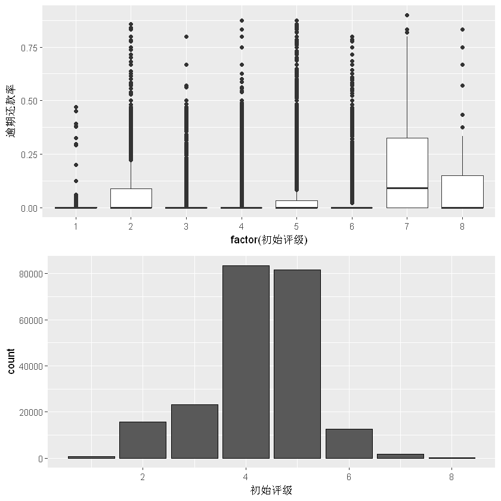

```r
p1<-ggplot(data=ppd,mapping=aes(x=factor(初始评级),y=逾期还款率))+
geom_boxplot()
p2<-ggplot(data=ppd,aes(初始评级))+
geom_bar(color='black')
#scale_x_continuous(limits=c(2,7),breaks=seq(2,6,1))
grid.arrange(p1,p2,ncol=1)
```

#### 小结：

#### 从箱线图可以卡出，各个初始评级的逾期还款率中位数一般都在零值附近，说明每个评级有50%的人都是没有违约的。

## 年龄与逾期还款率的关系：

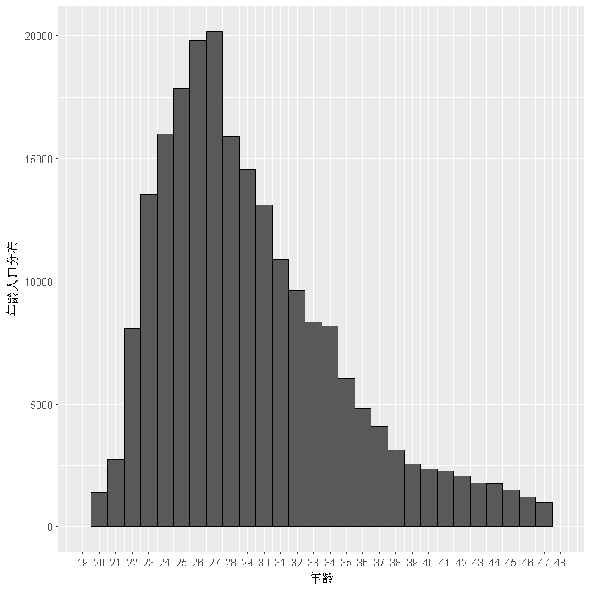

```r
ggplot(data=ppd,aes(年龄))+
geom_histogram(binwidth=1,color='black')+
scale_x_continuous(limits=c(19,48),breaks=seq(19,48,1))+
ylab('年龄人口分布')
```

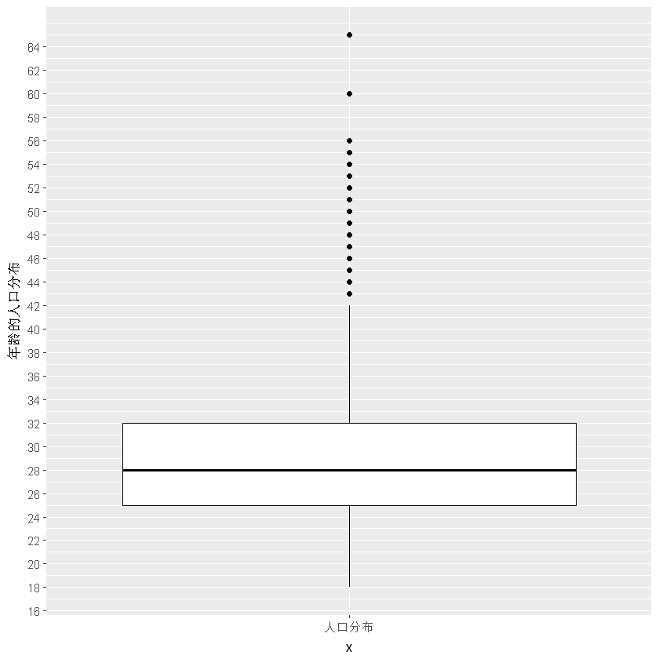

```r
ggplot(data=ppd,aes(x='人口分布',y=年龄))+
geom_boxplot(color='black')+
ylab('年龄的人口分布')+
scale_y_continuous(breaks=seq(0,65,2))
```

#### 去除掉48岁以上的异常值。

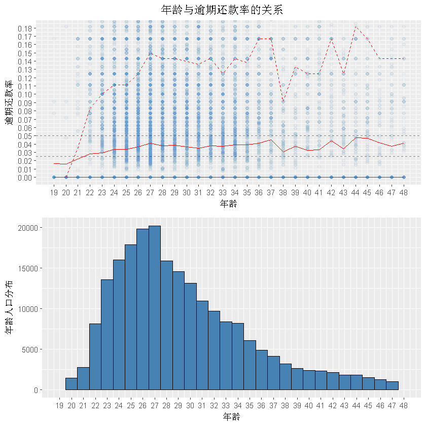

```r
p1<-ggplot(data=ppd,aes(x=年龄,y=逾期还款率))+
geom_point(color='steelblue',alpha=0.015)+
scale_color_brewer(type = 'div')+
geom_line(stat='summary',fun.y=mean,color='red')+
geom_line(linetype=2,stat='summary',fun.y = quantile,fun.args = list(probs=0.1),color='purple')+
geom_line(stat='summary',fun.y = quantile,fun.args = list(probs=0.5),color='red')+
geom_line(linetype=2,stat='summary',fun.y = quantile,fun.args = list(probs=0.9),color='red')+
coord_cartesian(ylim=c(0,0.18))+
geom_hline(linetype=2,yintercept=0.05,alpha=0.5)+
geom_hline(linetype=2,yintercept=0.025,alpha=0.5)+
#scale_y_continuous(breaks=seq(0,0.1,0.025))+
scale_x_continuous(limits=c(19,48),breaks=seq(19,48,1))+
scale_y_continuous(breaks=seq(0,0.20,0.01))+
ylab('逾期还款率')+
ggtitle('                                         年龄与逾期还款率的关系')

p2<-ggplot(data=ppd,aes(年龄))+
geom_histogram(binwidth=1,color='black',fill='steelblue')+
scale_x_continuous(limits=c(19,48),breaks=seq(19,48,1))+
ylab('年龄人口分布')

grid.arrange(p1,p2,ncol=1)
```

#### 逾期还款率中位数接近0，说明有50%的人是没有逾期的，平均逾期还款率在2.5%-5%之间，说明平台整体的逾期还款率水平在2.5%-5%。

#### 从图中可以看出90%的人的逾期还款率低于18%

#### 从图中我们可以看出年龄与逾期还款率之间是非单调的关系，我们打算找出19-48岁用户年龄和逾期还款率的相关性。

```r
with(subset(ppd,年龄<48),cor.test(ppd$年龄,ppd$逾期还款率,))
```

```
	Pearson's product-moment correlation

data:  ppd$年龄 and ppd$逾期还款率
t = 10.688, df = 218830, p-value < 2.2e-16
alternative hypothesis: true correlation is not equal to 0
95 percent confidence interval:
 0.01865364 0.02702883
sample estimates:
       cor
0.02284163
```

## 年龄，初始评级与逾期还款率的关系：

#### 去除掉48岁以上的异常值，研究总体趋势。

[figure not shown]

```r
p1<-ggplot(data=ppd,aes(x=年龄,y=逾期还款率,color=factor(初始评级)))+
geom_point()+
scale_color_brewer(type = 'div',
                     guide = guide_legend(title = '初始评级', reverse = F,
                                          override.aes = list(alpha = 1, size = 2)))+
#geom_line(stat='summary',fun.y=mean,color='red')+
coord_cartesian(ylim=c(0,0.1))+
#geom_hline(linetype=2,yintercept=0.05,alpha=0.5)+
#geom_hline(linetype=2,yintercept=0.025,alpha=0.5)+
scale_y_continuous(breaks=seq(0,0.1,0.025))+
scale_x_continuous(limits=c(19,48),breaks=seq(19,48,1))+
ylab('逾期还款率')+
ggtitle('                       年龄，初始评级与逾期还款率的关系')

p2<-ggplot(data=ppd,aes(年龄))+
geom_histogram(binwidth=1,color='black',fill='steelblue')+
scale_x_continuous(limits=c(19,48),breaks=seq(19,48,1))+
ylab('年龄人口分布')

grid.arrange(p1,p2,ncol=1)
```

#### 小结：

#### 从图中可以看出，各个年龄的，不同初始评级的，逾期还款率，几乎是无偏的均匀的散落在逾期还款率的取值范围内，看不出任何趋势。

# 借款人特征与逾期还款率平均值的关系：

### 操作定义：逾期还款率平均值 = mean（逾期还款率）

## 初始评级与逾期还款率均值的关系：

#### 备注：初始评级AAA-F已经依次被替换为1-8.

```r
ggplot(data=ppd,aes(x='人口分布',y=初始评级))+
geom_boxplot(color='black')+
scale_y_continuous(breaks=seq(1,8,1))+
ylab('初始评级的人口分布')
```

[output not shown]

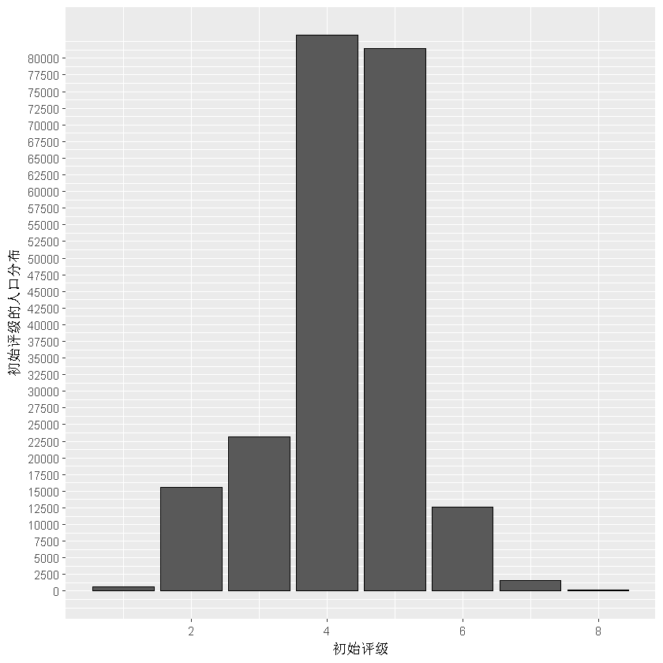

```r
ggplot(data=ppd,aes(初始评级))+
geom_bar(color='black')+
ylab('初始评级的人口分布')+
scale_y_continuous(breaks=seq(0,80000,2500))
```

#### 去除掉异常值AAA，E，F.研究总体趋势

```r
ratio<-ppd%>%
group_by(初始评级)%>%
summarise(逾期还款率均值=mean(逾期还款率),
         逾期还款率中位数=median(逾期还款率),
         逾期还款率最小值=min(逾期还款率),
         逾期还款率最大值=max(逾期还款率),
         n=n())
```

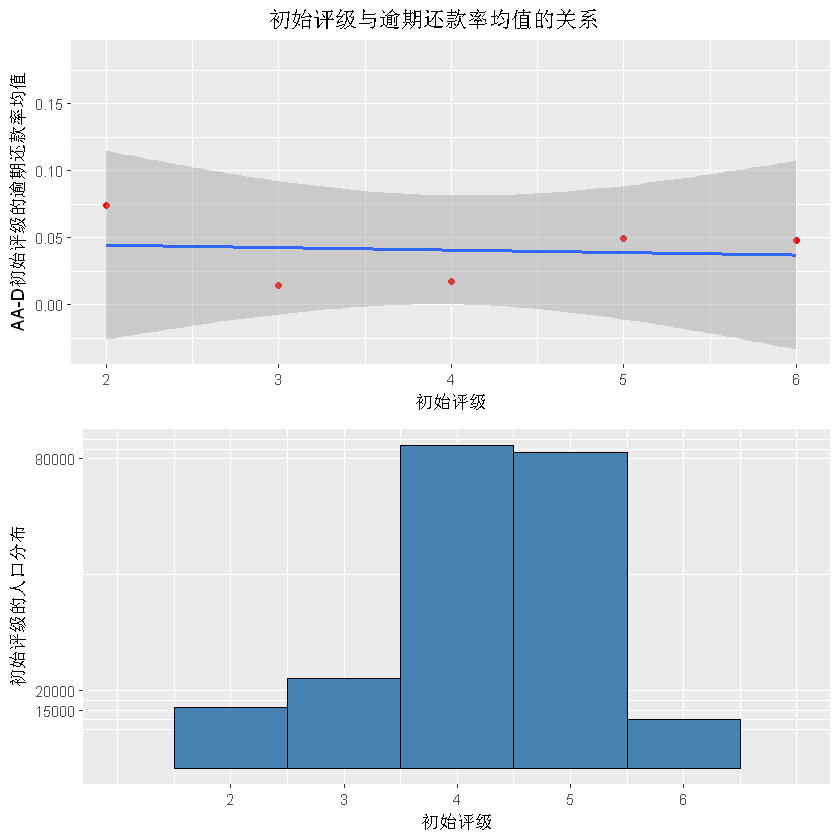

```r
#p1<-ggplot(data=ratio,aes(x=初始评级,y=逾期还款率均值))+
#geom_point(color='red')+
#geom_smooth(method='lm')+
#ylab('AAA-F初始评级的逾期还款率均值')+
#ggtitle('                                 初始评级与逾期还款率均值的关系')

p3<-ggplot(data=ppd,aes(初始评级))+
geom_histogram(binwidth=1,color='black',fill='steelblue')+
ylab('初始评级的人口分布')+
scale_y_continuous(breaks=c(15000,20000,80000))+
scale_x_continuous(limits=c(1,7),breaks=seq(2,6,1))


p2<-ggplot(data=ratio,aes(x=初始评级,y=逾期还款率均值))+
geom_point(color='red')+
geom_smooth(method='lm')+
scale_x_continuous(limits=c(2,6),breaks=seq(2,6,1))+
ylab('AA-D初始评级的逾期还款率均值')+
ggtitle('                                 初始评级与逾期还款率均值的关系')

grid.arrange(p2,p3,ncol=1)
```

```r
f<-ratio[c(-1,-7,-8),]
```

```r
cor.test(f$初始评级,f$逾期还款率均值,method='pearson')
```

```
	Pearson's product-moment correlation

data:  f$初始评级 and f$逾期还款率均值
t = -0.20303, df = 3, p-value = 0.8521
alternative hypothesis: true correlation is not equal to 0
95 percent confidence interval:
 -0.9056633  0.8535128
sample estimates:
       cor
-0.1164234
```

#### 小结：

# 借款人特征与（人口）坏账率的关系：

### 操作定义：（人口）坏账率 = （逾期超过90天的人口数）/（总人口数）

## 初始评级和（人口）坏账率的关系：

#### 备注：初始评级AAA-F已经依次被替换为1-8.

```r
ggplot(data=ppd,aes(x='人口分布',y=初始评级))+
geom_boxplot(color='black')+
scale_y_continuous(breaks=seq(1,8,1))+
ylab('初始评级的人口分布')
```

[output not shown]

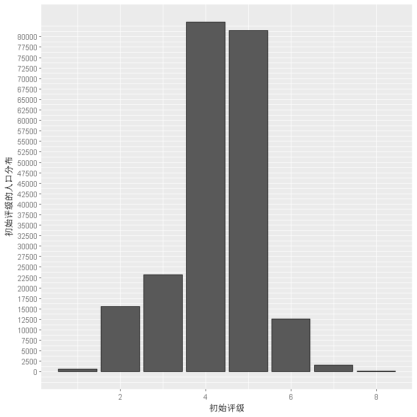

```r
ggplot(data=ppd,aes(初始评级))+
geom_bar(color='black')+
ylab('初始评级的人口分布')+
scale_y_continuous(breaks=seq(0,80000,2500))
```

#### 去除掉异常值AAA，E，F研究总体趋势。

```r
pj_hz_ratio<-ppd%>%
group_by(初始评级)%>%
summarise(人口坏账率=mean(标当前逾期天数),
         初始评级人口分布=n())
```

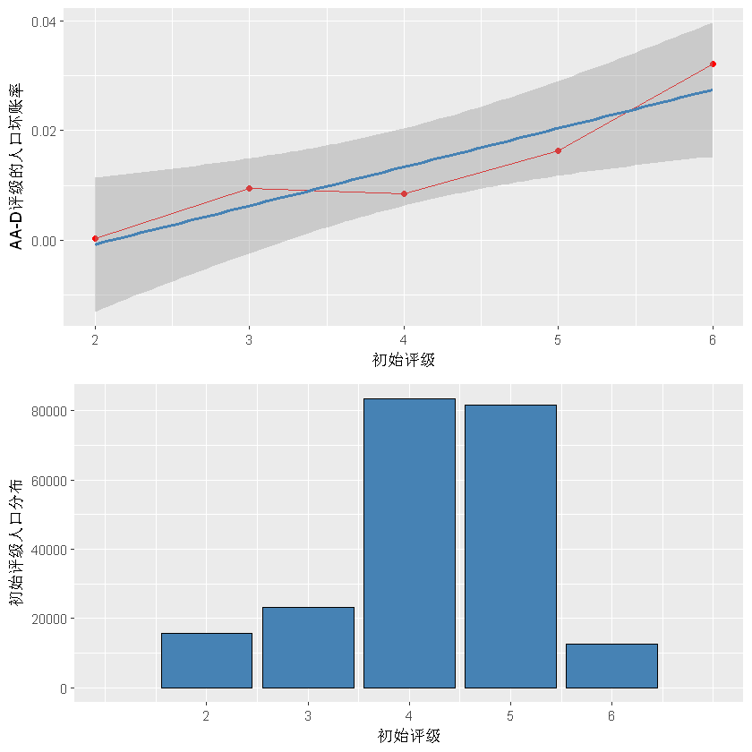

```r
#p1<-ggplot(data=pj_hz_ratio,aes(x=初始评级,y=人口坏账率))+
#geom_point(color='red')+
#scale_x_continuous(breaks=seq(1,8,1))+
#geom_line(color='steelblue')+
#ylab('AAA-F评级的人口坏账率')+
#ggtitle('                                           初始评级和人口坏账率的关系')


p2<-ggplot(data=pj_hz_ratio,aes(x=初始评级,y=初始评级人口分布))+
geom_bar(stat='identity',color='black',fill='steelblue')+
scale_x_continuous(lim=c(1,7),breaks=seq(2,6,1))

p3<-ggplot(data=pj_hz_ratio,aes(x=初始评级,y=人口坏账率))+
geom_point(color='red')+
geom_line(color='red')+
scale_x_continuous(limits=c(2,6),breaks=seq(2,6,1))+
geom_smooth(method='lm',color='steelblue')+
ylab('AA-D评级的人口坏账率')

grid.arrange(p3,p2,ncol=1)
```

```r
f<-pj_hz_ratio[c(-1,-7,-8),]
```

#### 计算人AA-D评级与人口坏账率的相关系数。

```r
cor.test(f$初始评级,f$人口坏账率,method='pearson')
```

```
	Pearson's product-moment correlation

data:  f$初始评级 and f$人口坏账率
t = 4.4994, df = 3, p-value = 0.0205
alternative hypothesis: true correlation is not equal to 0
95 percent confidence interval:
 0.2885847 0.9956894
sample estimates:
      cor
0.9332402
```

#### 小结：

#### 经计算，AA-D初始评级的人口坏账率和评级的相关系数达到了0.93非常接近1，我们可以说AA-D评级与人口坏账率之间具有高度相关性

#### 随着初始评级的下降，人口坏账率会明显上升，最大人口坏账率不超过3.2%

## 性别和（人口）坏账率的关系

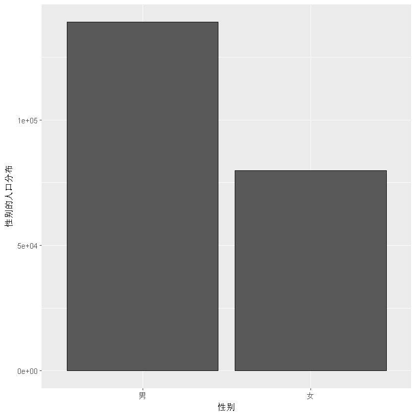

```r
ggplot(data=ppd,aes(性别))+
geom_bar(color='black')+
ylab('性别的人口分布')
```

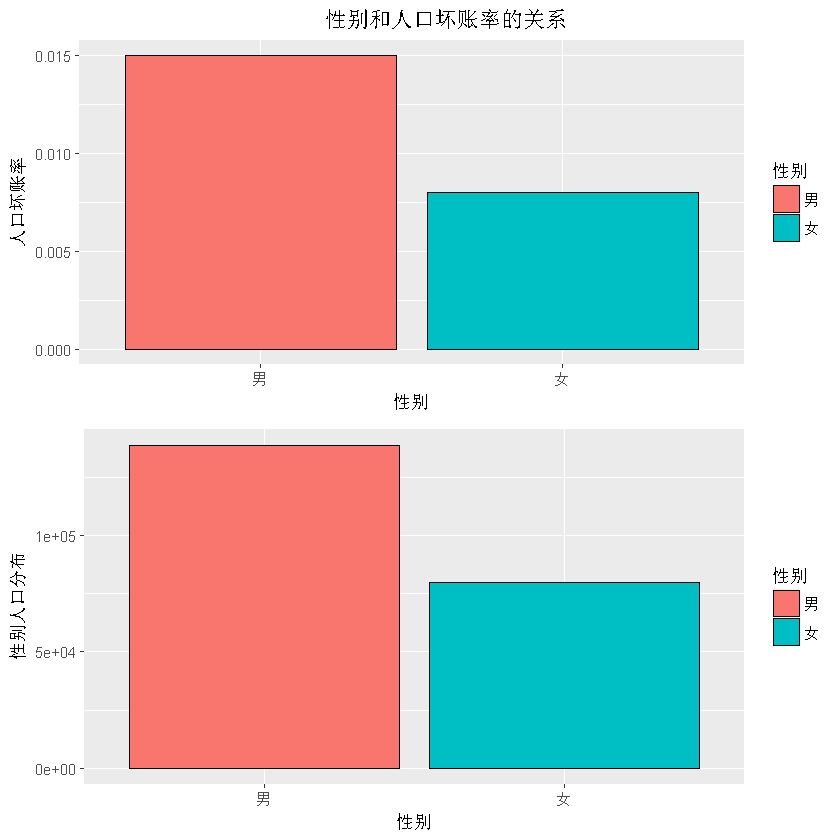

```r
p1<-ggplot(data=ppd,aes(x=性别,y=标当前逾期天数,fill=性别))+
geom_bar(stat='summary',fun.y=mean,color='black')+
ylab('人口坏账率')+
ggtitle('                                         性别和人口坏账率的关系')
p2<-ggplot(data=ppd,aes(性别,fill=性别))+
geom_bar(color='black')+
ylab('性别人口分布')
grid.arrange(p1,p2,ncol=1)
```

#### 小结：

#### 从柱状图可以看出男性的人口坏账率明显高于女性。

## 性别、初始评级和（人口）坏账率的关系：

#### 去除掉异常值：AAA级和E，F

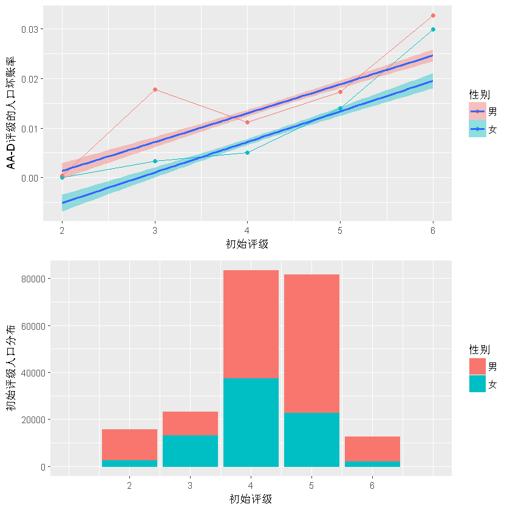

```r
#p1<-ggplot(data=ppd,aes(x=初始评级,y=标当前逾期天数,fill=性别))+
#geom_point(stat='summary',aes(color=性别),fun.y=mean)+
#geom_line(stat='summary',aes(color=性别),fun.y=mean)+
#scale_x_continuous(limits=c(1,8),breaks=seq(1,8,1))+
#ylab('AAA-F评级的人口坏账率')+
#ggtitle('                           性别、初始评级和人口坏账率的关系')

p2<-ggplot(data=ppd,aes(x=初始评级,fill=性别))+
geom_bar(aes(color=性别))+
scale_x_continuous(limits=c(1,7),breaks=seq(2,6,1))+
ylab('初始评级人口分布')

p3<-ggplot(data=ppd,aes(x=初始评级,y=标当前逾期天数,fill=性别))+
geom_point(stat='summary',aes(color=性别),fun.y=mean)+
geom_line(stat='summary',aes(color=性别),fun.y=mean)+
scale_x_continuous(limits=c(2,6),breaks=seq(2,6,1))+
geom_smooth(method='lm')+
ylab('AA-D评级的人口坏账率')
grid.arrange(p3,p2,ncol=1)
```

#### 小结：

#### 从AA-D的坏账率来看，基本上，随着初始评级的下降，无论男女的人口坏账率都是上升的趋势，最大人口坏账率达到3.2%

#### 重点研究下异常值AAA评级：

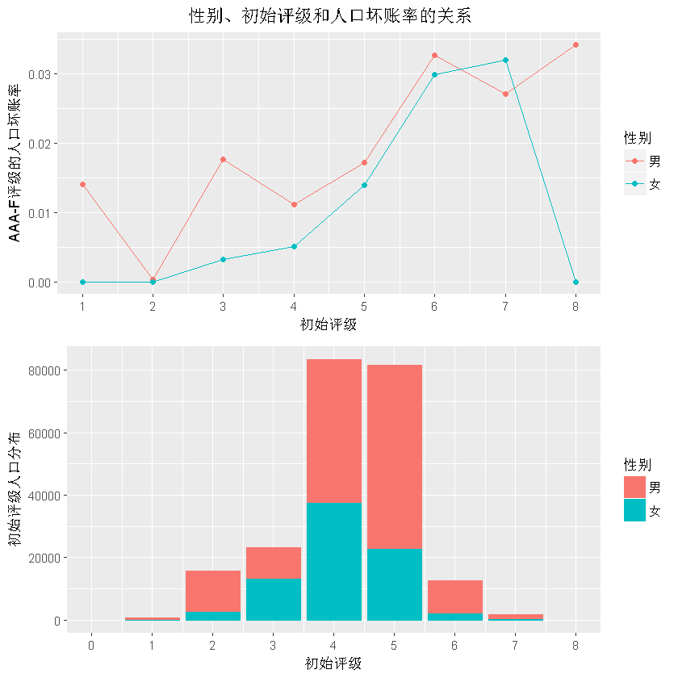

```r
p1<-ggplot(data=ppd,aes(x=初始评级,y=标当前逾期天数,fill=性别))+
geom_point(stat='summary',aes(color=性别),fun.y=mean)+
geom_line(stat='summary',aes(color=性别),fun.y=mean)+
scale_x_continuous(limits=c(1,8),breaks=seq(1,8,1))+
ylab('AAA-F评级的人口坏账率')+
ggtitle('                           性别、初始评级和人口坏账率的关系')

p2<-ggplot(data=ppd,aes(x=初始评级,fill=性别))+
geom_bar(aes(color=性别))+
scale_x_continuous(limits=c(0,8),breaks=seq(0,8,1))+
ylab('初始评级人口分布')

grid.arrange(p1,p2,ncol=1)
```

#### 小结：

#### 男性AAA评级的人口坏账率高达1.5%，男性AA评级等的人口坏账率低至0，这是很不正常的现象。

#### 按理说，评级越高，人口坏账率应该越低，可是在AAA评级的男性借款人身上却出现了反常的现象。

#### 因此我们怀疑，有部分男性，为了骗取高额借款然后一走了之，伪造了高信用评级的身份，骗取了拍拍贷平台的信任，获取了AAA评级。

#### 不明真相的投资者，由于平台的审核漏洞，投入了大量资金到AAA评级的借款人身上，却造成了高额坏账率。

# 借款人特征与（金额）坏账率的关系：

### 操作定义：（金额）坏账率 = （逾期超过90天的总待还金额数）/（总借款金额）

```r
names(ppd)
```

1. 'ListingId'

2. '借款金额'

3. '借款期限'

4. '借款利率'

5. '借款成功日期'

6. '初始评级'

7. '借款类型'

8. '是否首标'

9. '年龄'

10. '性别'

11. '手机认证'

12. '户口认证'

13. '视频认证'

14. '学历认证'

15. '征信认证'

16. '淘宝认证'

17. '历史成功借款次数'

18. '历史成功借款金额'

19. '总待还本金'

20. '历史正常还款期数'

21. '历史逾期还款期数'

22. '我的投资金额'

23. '当前到期期数'

24. '当前还款期数'

25. '已还本金'

26. '已还利息'

27. '待还本金'

28. '待还利息'

29. '标当前逾期天数'

30. '标当前状态'

31. '上次还款日期'

32. '上次还款本金'

33. '上次还款利息'

34. '下次计划还款日期'

35. '下次计划还款本金'

36. '下次计划还款利息'

37. 'recorddate'

38. '逾期还款率'

## 征信认证和金额坏账率的关系：

```r
levels(ppd$征信认证)
```

1. '成功认证'

2. '未成功认证'

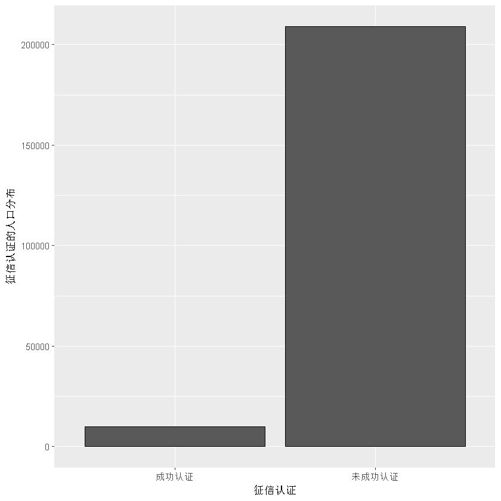

```r
ggplot(data=ppd,aes(征信认证))+
geom_bar(color='black')+
ylab('征信认证的人口分布')
```

```r
hz<-subset(ppd,ppd$标当前逾期天数==1)
```

```r
hz<-hz%>%
group_by(征信认证)%>%
summarise(坏账金额=sum(总待还本金))
```

```r
zj<-ppd%>%
group_by(征信认证)%>%
summarise(总借款金额=sum(历史成功借款金额),
         征信认证人口分布=n())
```

```r
zj_hz<-merge(zj,hz,all=T)
```

```r
zj_hz$金额坏账率<-zj_hz$坏账金额/zj_hz$总借款金额
```

```r
zj_hz
```

| 征信认证 | 总借款金额 | 征信认证人口分布 | 坏账金额 | 金额坏账率 |
| --- | --- | --- | --- | --- |
| 成功认证 | 96935558 | 9787 | 1678987 | 0.017320649 |
| 未成功认证 | 2177883886 | 209047 | 19478938 | 0.008943974 |

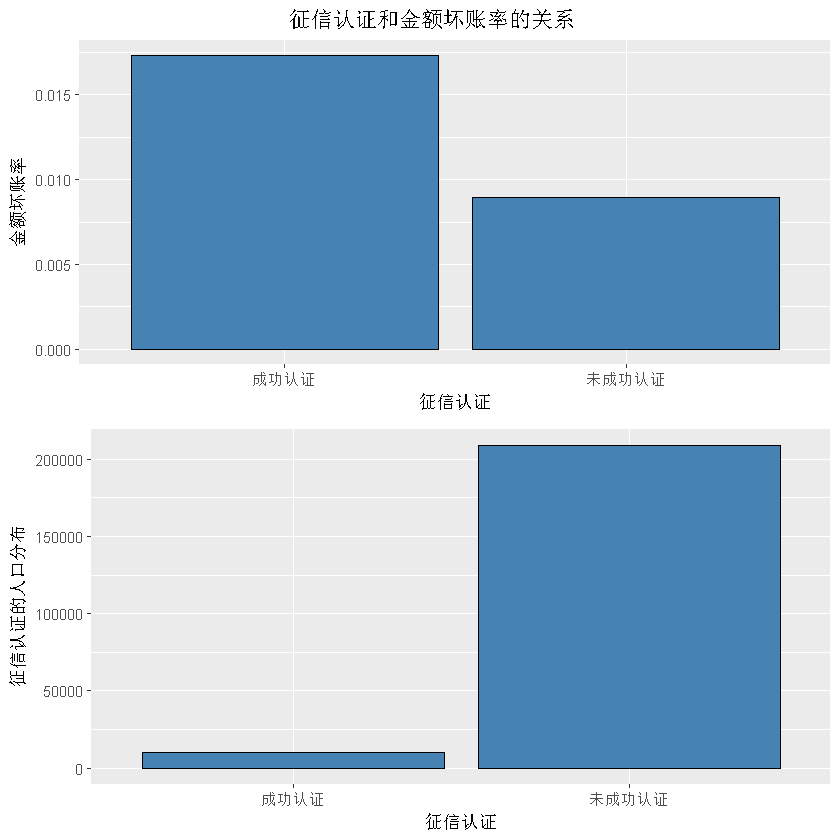

```r
p1<-ggplot(data=zj_hz,aes(x=征信认证,y=金额坏账率))+
geom_bar(stat='identity',color='black',fill='steelblue')+
ggtitle('                                   征信认证和金额坏账率的关系')

p2<-ggplot(data=zj_hz,aes(x=征信认证,y=征信认证人口分布))+
geom_bar(stat='identity',color='black',fill='steelblue')+
ylab('征信认证的人口分布')

grid.arrange(p1,p2,ncol=1)
```

#### 小结：

#### 从征信认证的人口分布可以看出，未成功认证的人占大多数，同时未成功认证的金额坏账率明显低于成功认证的标的。

#### 推测：未征信认证的人多很可能是怕隐私泄露，而担心隐私泄露的群体往往比较在乎自己的信誉，所以坏账率比认证的要低。

## 视频认证和金额坏账率的关系：

```r
levels(ppd$视频认证)
```

1. '成功认证'

2. '未成功认证'

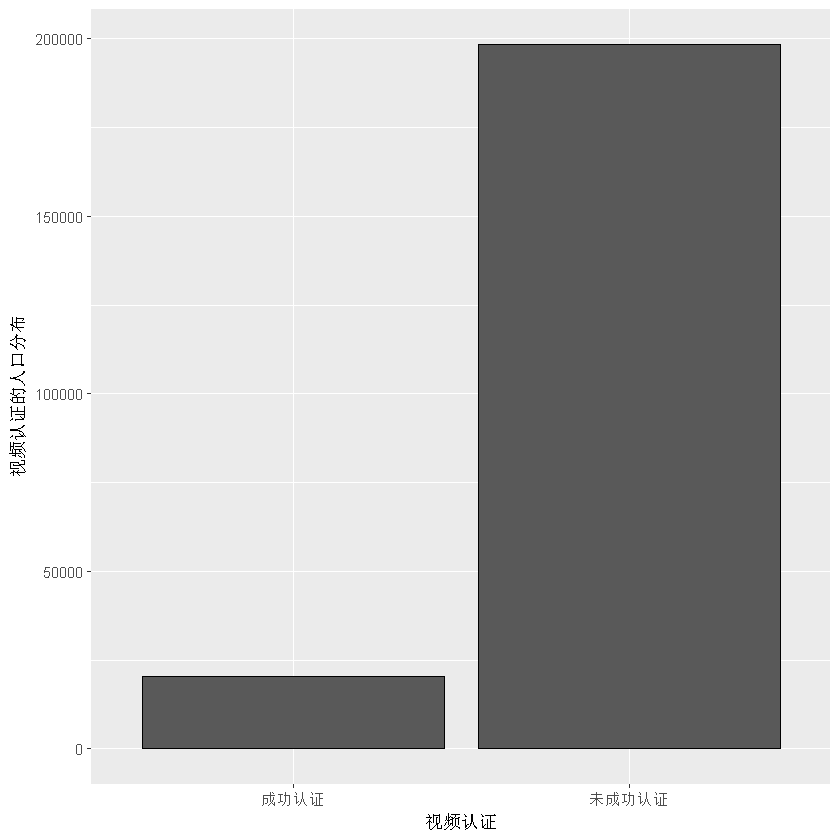

```r
ggplot(data=ppd,aes(视频认证))+
geom_bar(color='black')+
ylab('视频认证的人口分布')
```

```r
hz<-subset(ppd,标当前逾期天数==1)
```

```r
hz<-hz%>%
group_by(视频认证)%>%
summarise(坏账金额=sum(总待还本金))
```

```r
zj<-ppd%>%
group_by(视频认证)%>%
summarise(总借款金额 = sum(历史成功借款金额),
          视频认证人口分布=n())
```

```r
zj_hz<-merge(zj,hz,all=T)
```

```r
zj_hz$金额坏账率<-zj_hz$坏账金额/zj_hz$总借款金额
```

```r
zj_hz
```

| 视频认证 | 总借款金额 | 视频认证人口分布 | 坏账金额 | 金额坏账率 |
| --- | --- | --- | --- | --- |
| 成功认证 | 215470902 | 20383 | 9693159 | 0.044985931 |
| 未成功认证 | 2059348542 | 198451 | 11464766 | 0.005567181 |

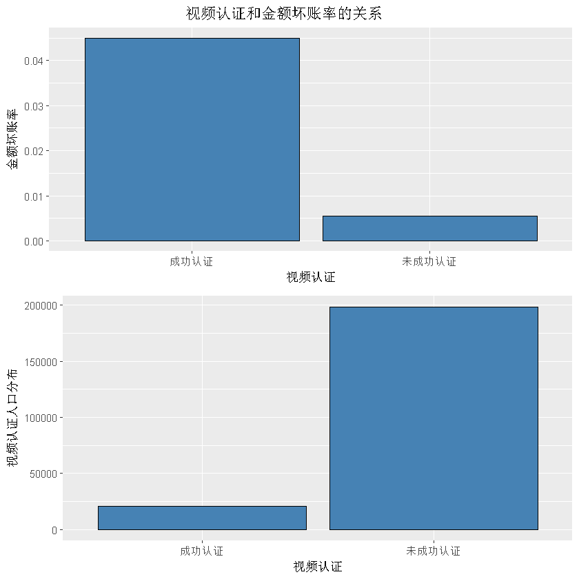

```r
p1<-ggplot(data=zj_hz,aes(x=视频认证,y=金额坏账率))+
geom_bar(stat='identity',color='black',fill='steelblue')+
ggtitle('                                 视频认证和金额坏账率的关系')

p2<-ggplot(data=zj_hz,aes(x=视频认证,y=视频认证人口分布))+
geom_bar(stat='identity',color='black',fill='steelblue')

grid.arrange(p1,p2,ncol=1)
```

#### 小结：

#### 图表说明，成功视频认证的用户的金额坏账率超过4.5%，远远超过未成功视频认证的用户的金额坏账率的0.5%。

#### 推测：没有认证的用户可能出于保护隐私的考虑，而注重隐私的用户通常是比较严谨守约的用户，所以没有认证的用户反而坏账更低。

#### 另外不注重隐私的用户可能是学生或者没有经济能力的借款人，只要能借到钱，并不在乎隐私的泄露，说明这部分用户很缺钱。¶

#### 非常缺钱的借款人有可能缺乏赚钱能力，故还款能力比较差，所以造成了很大的金额坏账率的产生。

## 户口认证和金额坏账率的关系：

```r
table(ppd$户口认证)
```

```
  成功认证 未成功认证
     20780     198054
```

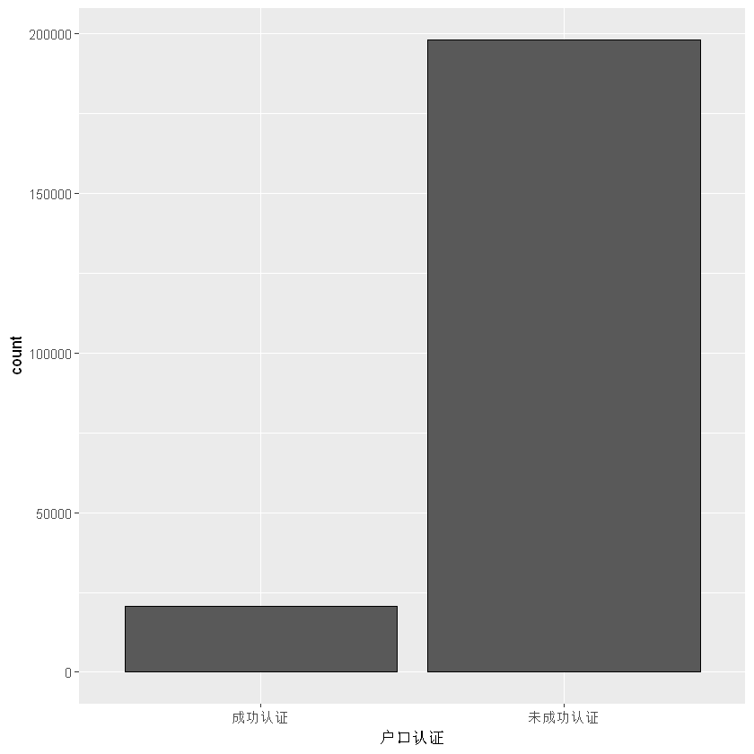

```r
ggplot(data=ppd,aes(户口认证))+
geom_bar(color='black')
```

```r
hz<-subset(ppd,ppd$标当前逾期天数==1)
```

```r
hz<-hz%>%
group_by(户口认证)%>%
summarise(坏账金额=sum(总待还本金))
```

```r
zj<-ppd%>%
group_by(户口认证)%>%
summarise(总借款金额=sum(历史成功借款金额),
         户口认证人口分布=n())
```

```r
zj_hz<-merge(zj,hz,all=T)
```

```r
zj_hz$金额坏账率<-zj_hz$坏账金额/zj_hz$总借款金额
```

```r
zj_hz
```

| 户口认证 | 总借款金额 | 户口认证人口分布 | 坏账金额 | 金额坏账率 |
| --- | --- | --- | --- | --- |
| 成功认证 | 225401800 | 20780 | 9554735 | 0.042389789 |
| 未成功认证 | 2049417644 | 198054 | 11603190 | 0.005661701 |

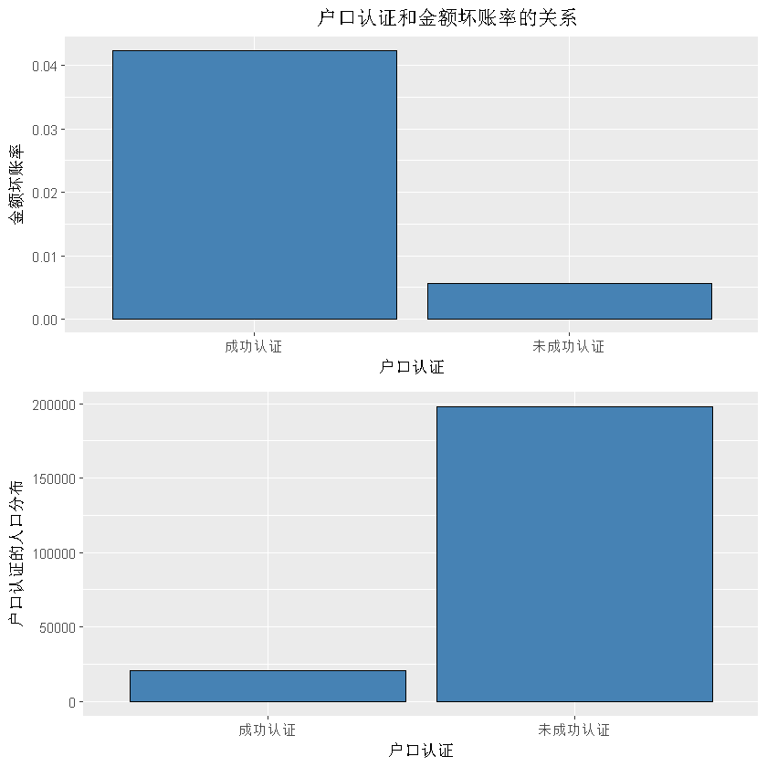

```r
p1<-ggplot(data=zj_hz,aes(x=户口认证,y=金额坏账率))+
geom_bar(stat='identity',color='black',fill='steelblue')+
ggtitle('                                              户口认证和金额坏账率的关系')
p2<-ggplot(data=ppd,aes(户口认证))+
geom_bar(color='black',fill='steelblue')+
ylab('户口认证的人口分布')
grid.arrange(p1,p2,ncol=1)
```

#### 推测：没有认证的用户可能出于保护隐私的考虑，而注重隐私的用户通常是比较严谨守约的用户，所以没有认证的用户反而坏账更低。

#### 另外不注重隐私的用户可能是学生或者没有经济能力的用户，只要能借到钱，并不在乎隐私的泄露，说明这部分用户很缺钱。

#### 非常缺钱的用户有可能缺乏赚钱能力，故还款能力比较差，所以造成了很大的金额坏账率的产生。

## 借款利率和金额坏账率的关系：

```r
summary(ppd$借款利率)
```

```
   Min. 1st Qu.  Median    Mean 3rd Qu.    Max.
   8.00   18.00   18.00   18.45   20.00   24.00
```

```r
table(ppd$借款利率)
```

```
    8  8.01  8.09   8.1  8.18  8.39   8.4   8.5  8.51  8.53  8.61   8.7     9
   10     5    10     5     5     5     5     5     5     5     5     5   150
 9.01  9.02  9.03  9.11  9.22  9.25  9.28   9.3  9.31  9.32  9.35  9.38  9.39
   26     5    20     5     5   101     5    20    10     5    10    10     5
  9.4  9.45   9.5  9.51  9.53  9.58   9.6  9.61  9.68   9.7  9.71  9.75  9.79
    5     5   522    25     5     5    15     5     5     5     5     5     5
 9.88  9.89   9.9    10 10.01  10.5    11  11.5    12    13    14    15    16
    5     5     5  1494     5  2492  1471  1538  8149    10  1405   925 23474
   17    18 18.01  18.3    19    20  20.5    21    22    23    24
   50 82776     5     6    37 56398     7    80 37117    58   263
```

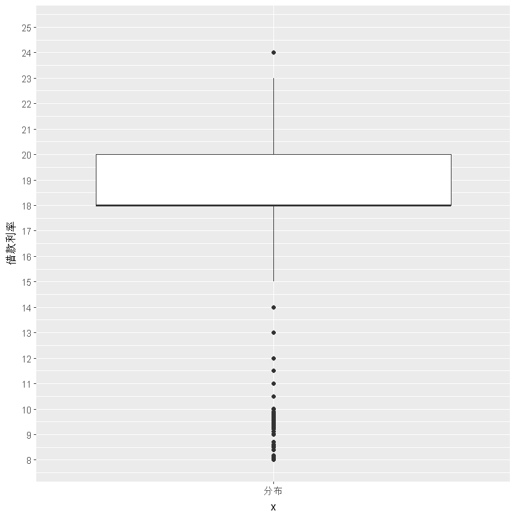

```r
ggplot(data=ppd,aes(x='分布',y=借款利率))+
geom_boxplot()+
scale_y_continuous(limits=c(8,25),breaks=seq(8,25,1))
```

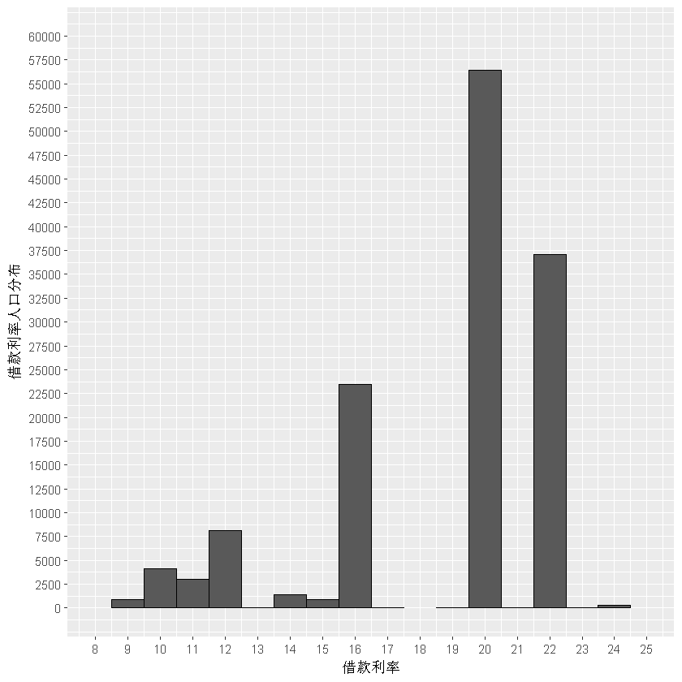

```r
ggplot(data=ppd,aes(x=借款利率))+
geom_histogram(binwidth=1,color='black')+
scale_x_continuous(limits=c(8,25),breaks=seq(8,25,1))+
scale_y_continuous(limits=c(0,60000),breaks=seq(0,60000,2500))+
ylab('借款利率人口分布')
```

```r
hz<-subset(ppd,标当前逾期天数==1)
```

```r
hz<-hz%>%
group_by(借款利率)%>%
summarise(坏账金额=sum(总待还本金))
```

```r
zj<-ppd%>%
group_by(借款利率)%>%
summarise(借款总金额=sum(历史成功借款金额),
         借款利率人口分布=n())
```

```r
zj_hz<-merge(zj,hz,all=T)
```

```r
zj_hz[is.na(zj_hz)]<-0
```

```r
zj_hz$金额坏账率<-(zj_hz$坏账金额)/(zj_hz$借款总金额)
```

#### 总待还本金比总借款金额还要高，明显是数据错误，这里需要去除掉利率等于9的数据。

```r
f<-subset(ppd,借款利率==9)
```

```r
sum(f$总待还本金)
```

14271489.18

```r
sum(f$历史成功借款金额)
```

1650415

```r
k<-subset(ppd,借款利率==17)
```

```r
length(k$历史成功借款金额)
```

50

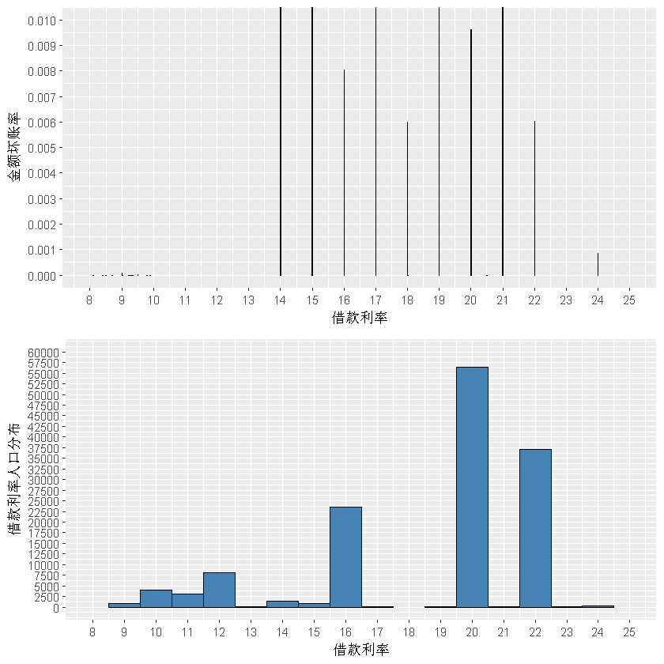

```r
p1<-ggplot(data=subset(zj_hz,!(借款利率==9)),aes(x=借款利率,y=金额坏账率))+
geom_bar(stat='identity',color='black',fill='steelblue')+
scale_x_continuous(limits=c(8,25),breaks=seq(8,25,1))+
scale_y_continuous(limits=c(0,0.6),breaks=seq(0,0.6,0.001))+
coord_cartesian(ylim=c(0,0.01))
p2<-ggplot(data=ppd,aes(x=借款利率))+
geom_histogram(binwidth=1,color='black',fill='steelblue')+
scale_x_continuous(limits=c(8,25),breaks=seq(8,25,1))+
scale_y_continuous(limits=c(0,60000),breaks=seq(0,60000,2500))+
ylab('借款利率人口分布')
grid.arrange(p1,p2,ncol=1)
```

## 手机认证和（金额）坏账率的关系：

```r
table(ppd$手机认证)
```

```
  成功认证 未成功认证
    122391      96443
```

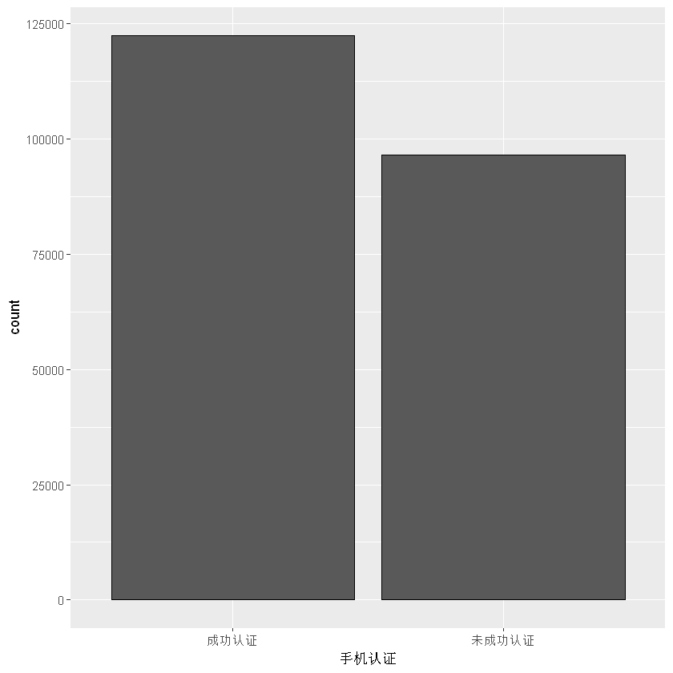

```r
ggplot(data=ppd,aes(手机认证))+
geom_bar(color='black')
```

```r
hz<-subset(ppd,标当前逾期天数==1)
```

```r
hz<-hz%>%
group_by(手机认证)%>%
summarise(坏账金额=sum(总待还本金))
```

```r
zj<-ppd%>%
group_by(手机认证)%>%
summarise(总借款金额=sum(历史成功借款金额),
         手机认证人口分布=n())
```

```r
zj_hz<-merge(zj,hz,all=T)
```

```r
zj_hz
```

| 手机认证 | 总借款金额 | 手机认证人口分布 | 坏账金额 |
| --- | --- | --- | --- |
| 成功认证 | 1233528617 | 122391 | 17573149 |
| 未成功认证 | 1041290827 | 96443 | 3584775 |

```r
zj_hz$金额坏账率<-(zj_hz$坏账金额)/(zj_hz$总借款金额)
```

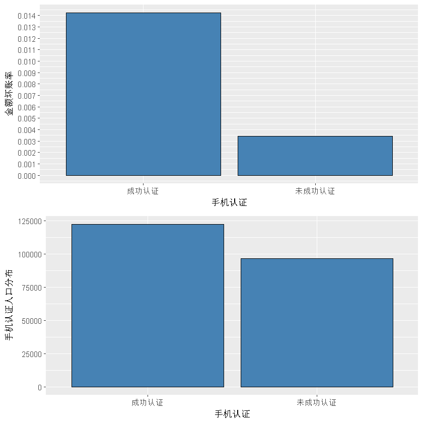

```r
p1<-ggplot(data=zj_hz,aes(x=手机认证,y=金额坏账率))+
geom_bar(stat='identity',color='black',fill='steelblue')+
scale_y_continuous(breaks=seq(0,0.02,0.001))
p2<-ggplot(data=zj_hz,aes(x=手机认证,y=手机认证人口分布))+
geom_bar(stat='identity',color='black',fill='steelblue')+
ylab('手机认证人口分布')

grid.arrange(p1,p2,ncol=1)
```

## 借款期限和（金额）坏账率的关系：

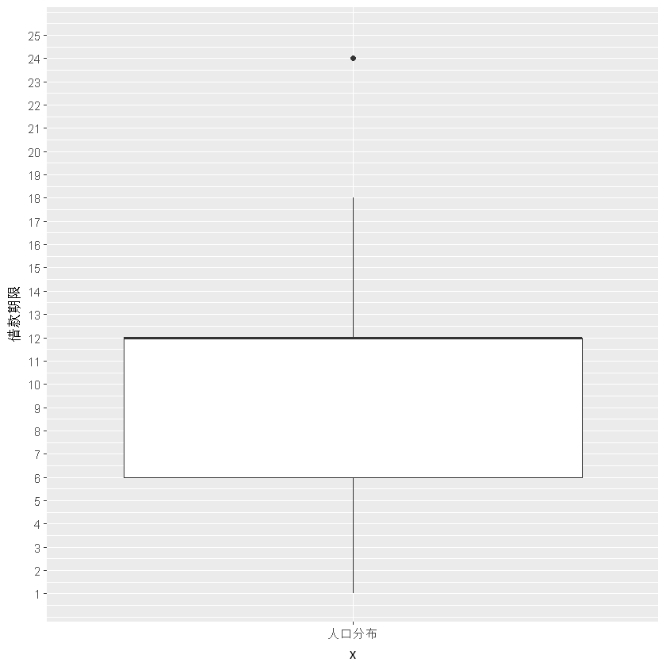

```r
ggplot(data=ppd,aes(x='人口分布',y=借款期限))+
geom_boxplot()+
scale_y_continuous(limits=c(1,25),breaks=seq(1,25,1))
```

#### 从箱线图来看24个月的借款期限，是一个异常值，需要重点研究。

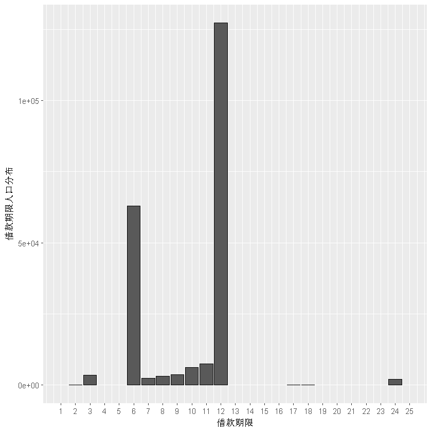

```r
ggplot(data=ppd,aes(借款期限))+
geom_bar(color='black')+
scale_x_continuous(limits=c(1,25),breaks=seq(1,25,1))+
ylab('借款期限人口分布')
```

```r
hz<-subset(ppd,标当前逾期天数==1)
```

```r
qx_hz<-hz%>%
group_by(借款期限)%>%
summarise(坏账金额=sum(总待还本金))
```

```r
qx_zj<-ppd%>%
group_by(借款期限)%>%
summarise(总借款金额=sum(历史成功借款金额),
         借款期限人口分部=n())
```

```r
qx_zj_hz<-merge(qx_zj,qx_hz,all=T)
```

```r
qx_zj_hz[is.na(qx_zj_hz)]<-0
```

```r
qx_zj_hz$金额坏账率<-(qx_zj_hz$坏账金额)/(qx_zj_hz$总借款金额)
```

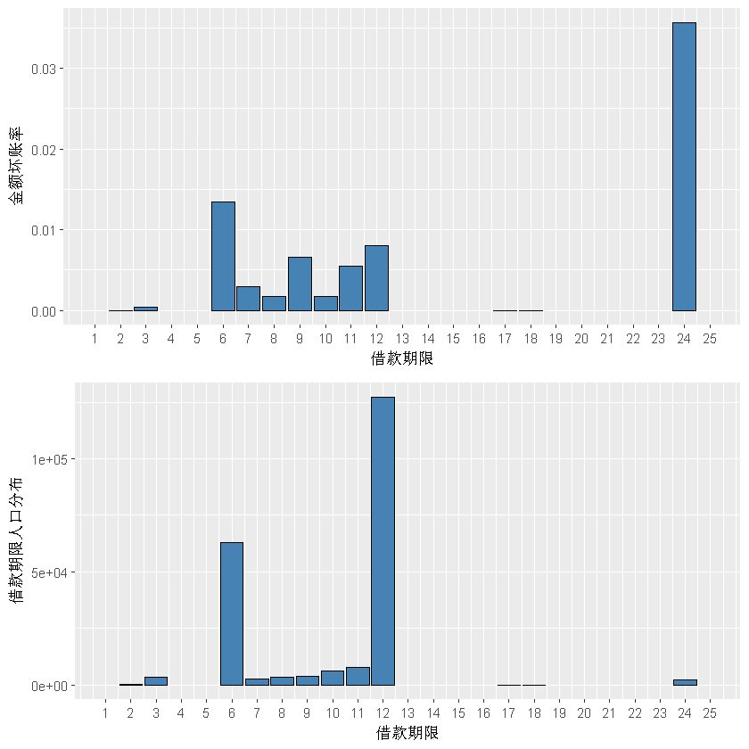

```r
p1<-ggplot(data=qx_zj_hz,aes(x=借款期限,y=金额坏账率))+
geom_bar(stat='identity',color='black',fill='steelblue')+
scale_x_continuous(limits=c(1,25),breaks=seq(1,25,1))

p2<-ggplot(data=ppd,aes(借款期限))+
geom_bar(color='black',fill='steelblue')+
scale_x_continuous(limits=c(1,25),breaks=seq(1,25,1))+
ylab('借款期限人口分布')

grid.arrange(p1,p2,ncol=1)
```

#### 小结：

#### 从金额坏账率的柱状图可以看出，24个月借款期限的坏账率最高，推测这并不是一个偶然的情况。

#### 因为老赖可能会故意选择借款期限最长的时间，而还款能力差的人因为没有能力还款也会尽量选择延后还款。

#### 结果就是，选择了24个月借款期限的人，要不就是没有能力还款而坏账，要不就是根本没有打算还款而坏账。

#### 所以，在拍拍投资，最好不要选择借款期限为24个月的借款人，以免血本无归。

## 年龄和（金额）坏账率的关系：

#### 备注：标当前预期天数大于等于90天的已经在数据清洗中被替换为1，小于90天的被替换为0.

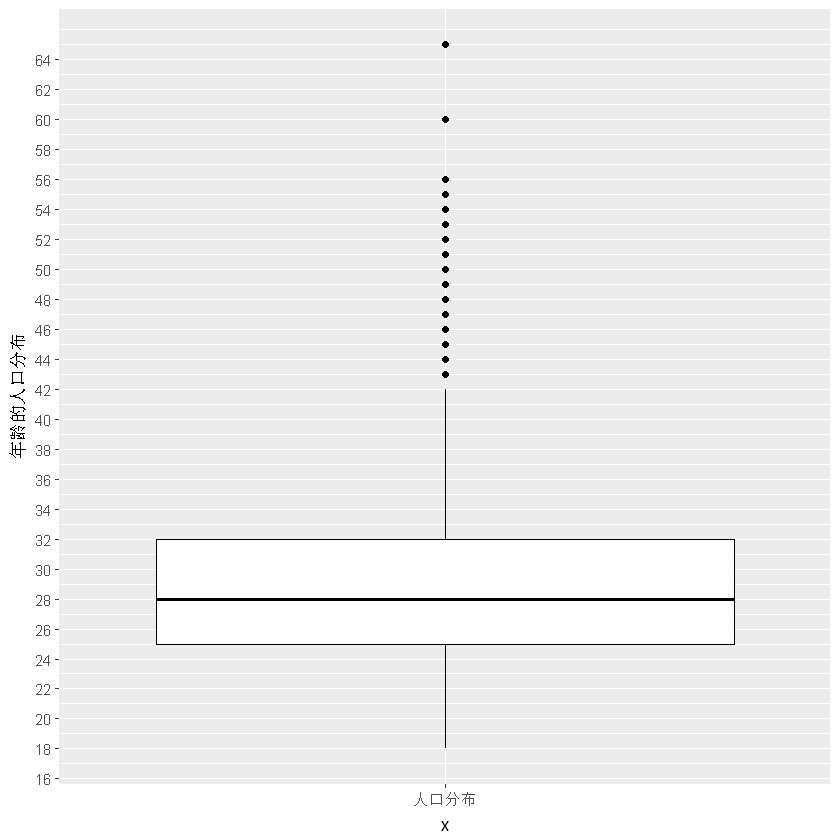

```r
ggplot(data=ppd,aes(x='人口分布',y=年龄))+
geom_boxplot(color='black')+
ylab('年龄的人口分布')+
scale_y_continuous(breaks=seq(0,65,2))
```

#### 去除掉42岁以上的异常值，研究总体趋势。

```r
hz<-subset(ppd,标当前逾期天数==1)
```

```r
nl_hz<-hz%>%
group_by(年龄)%>%
summarise(坏账金额=sum(总待还本金))
```

```r
nl_zj<-ppd%>%
group_by(年龄)%>%
summarise(总借款金额=sum(历史成功借款金额),
         总借款金额人口分布=n())
```

```r
nl_zj_hz<-merge(nl_zj,nl_hz,by='年龄',all=T)
```

```r
nl_zj_hz[is.na(nl_zj_hz)]<-0
```

```r
nl_zj_hz$金额坏账率<-(nl_zj_hz$坏账金额)/(nl_zj_hz$总借款金额)
```

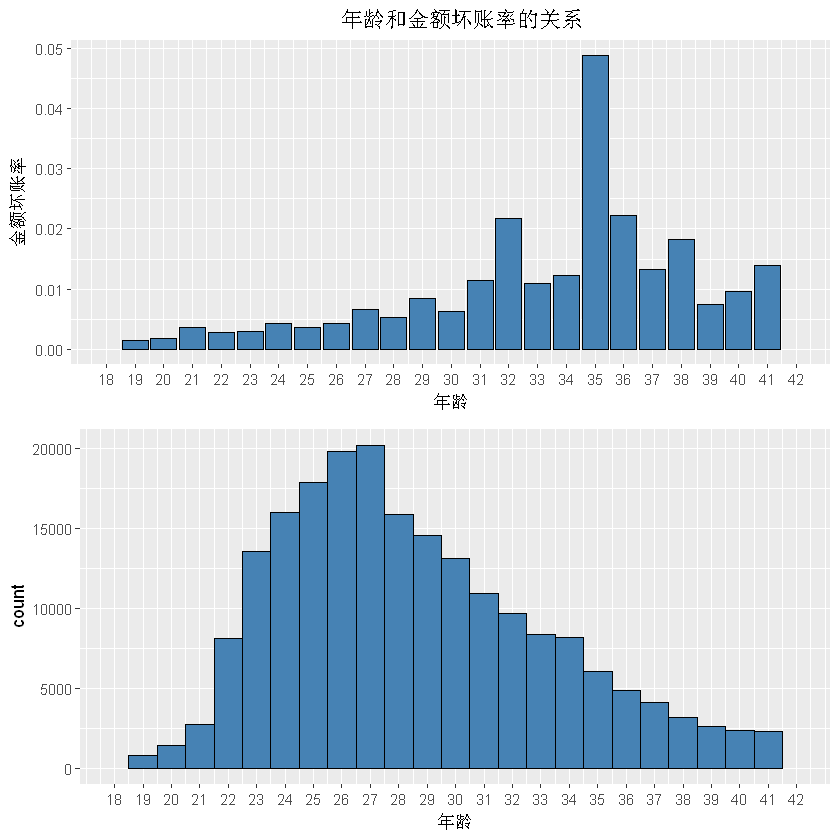

```r
p1<-ggplot(data=nl_zj_hz,aes(x=年龄,y=金额坏账率))+
geom_bar(stat='identity',color='black',fill='steelblue')+
ggtitle('                                             年龄和金额坏账率的关系')+
scale_x_continuous(limits=c(18,42),breaks=seq(18,42,1))
p2<-ggplot(data=ppd,aes(年龄))+
geom_histogram(binwidth=1,color='black',fill='steelblue')+
scale_x_continuous(limits=c(18,42),breaks=seq(18,42,1))

grid.arrange(p1,p2,ncol=1)
```

#### 35岁的坏账率达到5%是所有年龄中最高的，19-26岁的坏账率相对较低，都在0.5%以内。

#### 所以如果在拍拍贷投资，最好选择26岁以下的借款人，千万不要选择35岁的借款人。

## 初始评级和（金额）坏账率的关系：

#### 备注：初始评级AAA-F已经依次被替换为1-8.

```r
ggplot(data=ppd,aes(x='人口分布',y=初始评级))+
geom_boxplot(color='black')+
scale_y_continuous(breaks=seq(1,8,1))+
ylab('初始评级的人口分布')
```

[output not shown]

#### 去除掉异常值1,7,8，即AAA，F，E，研究总体趋势。

```r
hz<-subset(ppd,标当前逾期天数==1)
```

```r
hz<-hz%>%
group_by(初始评级)%>%
summarise(坏账金额=sum(总待还本金))
```

```r
zj<-ppd%>%
group_by(初始评级)%>%
summarise(总借款金额=sum(历史成功借款金额),
         初始评级人口分布=n())
```

```r
hz$总借款金额<-zj$总借款金额
```

```r
hz$金额坏账率<-(hz$坏账金额)/(hz$总借款金额)
```

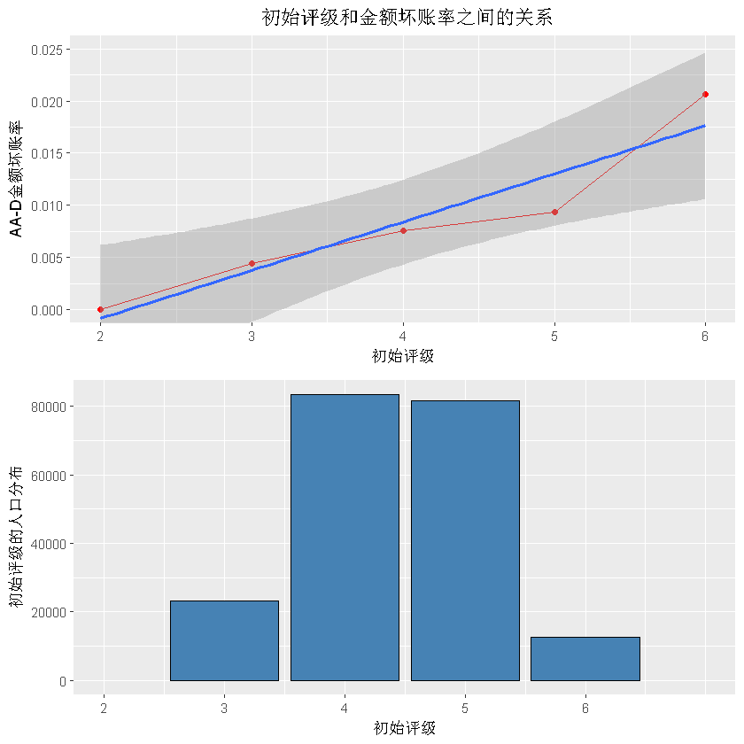

```r
#p1<-ggplot(data=hz,aes(x=初始评级,y=金额坏账率))+
#geom_point(color='red')+
#geom_line(color='steelblue')+
#ylab('AAA-F金额坏账率')+
#ggtitle('                                    初始评级和金额坏账率之间的关系')

p2<-ggplot(data=ppd,aes(初始评级))+
geom_bar(color='black',fill='steelblue')+
ylab('初始评级的人口分布')+
scale_x_continuous(limits=c(2,7),breaks=seq(2,6,1))


p3<-ggplot(data=hz,aes(x=初始评级,y=金额坏账率))+
geom_point(color='red')+
geom_line(color='red')+
geom_smooth(method='lm')+
scale_x_continuous(limits=c(2,6))+
coord_cartesian(ylim=c(0,0.025))+
ylab('AA-D金额坏账率')+
ggtitle('                                    初始评级和金额坏账率之间的关系')

grid.arrange(p3,p2,ncol=1)
```

```r
hz<-hz[c(-1,-7,-8),]
```

```r
cor.test(hz$初始评级,hz$金额坏账率)
```

```
	Pearson's product-moment correlation

data:  hz$初始评级 and hz$金额坏账率
t = 5.1187, df = 3, p-value = 0.01443
alternative hypothesis: true correlation is not equal to 0
95 percent confidence interval:
 0.3955041 0.9966163
sample estimates:
      cor
0.9472404
```

#### 小结：

#### 通过折线图以及相关系数0.947我们可以得知，初始评级的AA-D评级与金额坏账率之间存在极强的相关性。

#### 随着初始评级的下降，金额坏账率是一个持续上升的趋势。最大金额坏账率不超过2.2%

#### 对异常值AAA评级与金额还账率关系的研究：

[figure not shown]

```r
p1<-ggplot(data=hz,aes(x=初始评级,y=金额坏账率))+
geom_point(color='red')+
geom_line(color='steelblue')+
ylab('AAA-F金额坏账率')+
scale_y_continuous(limits=c(0,0.4),breaks=seq(0,0.4,0.02))+
ggtitle('                                    初始评级和金额坏账率之间的关系')

p2<-ggplot(data=ppd,aes(初始评级))+
geom_bar(color='black',fill='steelblue')+
ylab('初始评级的人口分布')+
scale_x_continuous(limits=c(0,8),breaks=seq(0,8,1))

grid.arrange(p1,p2,ncol=1)
```

#### AAA评级的金额坏账率高达38%是非常不可思议的，按理说，评级越高，坏账率应该越高，这才符合评级的目的。

#### 这里的AAA评级的坏账率已经大大超过了其它评级到不可思议的地步，分析原因：

#### 推测是有人恶意伪造了高信用等级的身份，导致网站给与了这些恶意骗贷的人AAA的最高初始评级。

#### 而不明真相的吃瓜群冲还误以为AAA评级的坏账率一定是最低的，结果导致大量的巨额骗贷产生，散户宣誓惨重。

#### 投资建议：对于AAA评级的投资标的，投资人一定要小心谨慎，甚至尽量避免，AA评级的标的也许是最佳选择。